# TIL: Won’t Predict via Disagreement

Learning from Teachers, more Literally

Vincent Warmerdam koaning.io  
2022-05-17

I’m generally interested in techniques that allow machine learning techniques to raise a [won’t predict flag](https://koaning.io/posts/high-on-probability-low-on-certainty/). One technique that I learned about recently involves leveraging annotators for this task. It’s described in [this paper](https://arxiv.org/pdf/2110.05719.pdf).

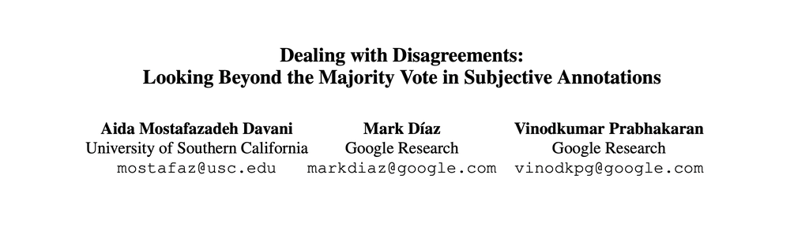

Many teams might combine annotations from a group of annotators by majority vote. One of the realizations that I had while glancing through this paper is that you may also use any annotator disagreement in other ways too.

[figure not shown]

You could, for example, try to predict the output label of each annotator. Then in production, you can try to predict if the annotators would disagree on a label. That might allow you to raise a “won’t predict” flag.

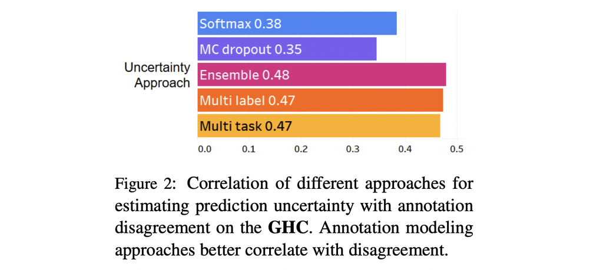

The paper suggests that this works better than training a single model on the majority label and using softmax or dropout samples as a proxy.

The paper makes a few more points, but this general idea makes a lot of sense in my mind. The annotation preferences of each annotator could be learned and might help indicate examples that aren’t 100% clear cut. This could be useful when trying to find bad labels, but it could also help detect ambigious examples that could be treated more carefully.